# Homework5DarrylNagal

Darryl Nagal

2025-11-08

## Assigning the csv file as SLSII after importing dataset

```r
library(tidyverse)
SLSII <- read_csv("~/Downloads/SLSII_PFT_clin_baseline.csv")
```

## Str provides a concise summary of the dataset

```r
str(SLSII)
```

```
## spc_tbl_ [97 × 12] (S3: spec_tbl_df/tbl_df/tbl/data.frame)
##  $ ScreenID           : chr [1:97] "01-J-S-S103" "02-AGR-S103" "02-AML-S122" "02-CAB-S104" ...
##  $ Treatment          : chr [1:97] "MMF" "MMF" "CYC" "MMF" ...
##  $ FVC_predicted      : num [1:97] 0.805 0.661 0.811 0.61 0.525 ...
##  $ TLC_liter          : num [1:97] 3.71 4.11 4.01 2.92 3.52 ...
##  $ DLCO_predicted     : num [1:97] 0.501 0.686 0.801 0.462 0.466 ...
##  $ Male               : num [1:97] 0 0 0 0 0 0 0 1 1 0 ...
##  $ age                : num [1:97] 47.4 50 54.9 40 70.4 ...
##  $ mrss_n1            : num [1:97] 27 7 32 10 39 2 5 5 41 19 ...
##  $ BDI                : num [1:97] 9 9 12 7 8 9 6 6 10 8 ...
##  $ disease_duration_yr: num [1:97] 2.58 2.25 1.02 1.85 4.92 ...
##  $ Raynaud_Diag_yn    : num [1:97] 1 1 1 1 1 1 1 1 1 1 ...
##  $ Ray_duration_yr    : num [1:97] 2.58 6.67 1.02 1.6 4.66 ...
##  - attr(*, "spec")=
##   .. cols(
##   ..   ScreenID = col_character(),
##   ..   Treatment = col_character(),
##   ..   FVC_predicted = col_double(),
##   ..   TLC_liter = col_double(),
##   ..   DLCO_predicted = col_double(),
##   ..   Male = col_double(),
##   ..   age = col_double(),
##   ..   mrss_n1 = col_double(),
##   ..   BDI = col_double(),
##   ..   disease_duration_yr = col_double(),
##   ..   Raynaud_Diag_yn = col_double(),
##   ..   Ray_duration_yr = col_double()
##   .. )
##  - attr(*, "problems")=<externalptr>
```

## Glimpse provides another summary of the dataset in a way that is easier to digest than Str

```r
library(dplyr)

glimpse(SLSII)
```

```
## Rows: 97
## Columns: 12
## $ ScreenID            <chr> "01-J-S-S103", "02-AGR-S103", "02-AML-S122", "02-C…
## $ Treatment           <chr> "MMF", "MMF", "CYC", "MMF", "MMF", "CYC", "CYC", "…
## $ FVC_predicted       <dbl> 0.8049215, 0.6609544, 0.8114863, 0.6095501, 0.5254…
## $ TLC_liter           <dbl> 3.710000, 4.113333, 4.006667, 2.923333, 3.523333, …
## $ DLCO_predicted      <dbl> 0.5008026, 0.6855451, 0.8005001, 0.4623120, 0.4659…
## $ Male                <dbl> 0, 0, 0, 0, 0, 0, 0, 1, 1, 0, 0, 1, 0, 0, 1, 1, 0,…
## $ age                 <dbl> 47.37534, 49.95617, 54.90411, 40.00548, 70.42740, …
## $ mrss_n1             <dbl> 27, 7, 32, 10, 39, 2, 5, 5, 41, 19, 6, 17, 5, 20, …
## $ BDI                 <dbl> 9, 9, 12, 7, 8, 9, 6, 6, 10, 8, 8, 7, 6, 10, 1, 9,…
## $ disease_duration_yr <dbl> 2.5753420, 2.2493150, 1.0191780, 1.8547950, 4.9150…
## $ Raynaud_Diag_yn     <dbl> 1, 1, 1, 1, 1, 1, 1, 1, 1, 1, 1, 1, 1, 1, 1, 1, 1,…
## $ Ray_duration_yr     <dbl> 2.5753420, 6.6712330, 1.0191780, 1.6027400, 4.6630…
```

## Dim returns the dimensions of the dataframe

```r
dim(SLSII)
```

```
## [1] 97 12
```

## Nrow counts the number of rows in the SLSII dataframe

```r
nrow(SLSII)
```

```
## [1] 97
```

## Ncol counts the number of columns in the SLSII dataframe

```r
ncol(SLSII)
```

```
## [1] 12
```

## 1:3 allows R to select the first three rows, while 1:5 after the comma selects the first five columns

```r
SLSII[1:3,1:5]
```

```
## # A tibble: 3 × 5
##   ScreenID    Treatment FVC_predicted TLC_liter DLCO_predicted
##   <chr>       <chr>             <dbl>     <dbl>          <dbl>
## 1 01-J-S-S103 MMF               0.805      3.71          0.501
## 2 02-AGR-S103 MMF               0.661      4.11          0.686
## 3 02-AML-S122 CYC               0.811      4.01          0.801
```

## Mean allows the calculation of the variable “age” in the SLSII dataframe, which is selected by using $

```r
mean(SLSII$age)
```

```
## [1] 51.58783
```

## Var calculates the variance of the variable “age” in the SLSII dataframe

```r
var(SLSII$age)
```

```
## [1] 81.71442
```

## Summary offers summary statistics which include the min, 1st quartile, median, mean, 3rd quartile, and max values

```r
summary(SLSII$age)
```

```
##    Min. 1st Qu.  Median    Mean 3rd Qu.    Max.
##   29.99   44.43   51.88   51.59   58.39   70.43
```

## Na.rm stands for “not available, remove”, and T declares the removal of missing values. This removes missing values before the mean is calculated

```r
mean(SLSII$age,na.rm=T)
```

```
## [1] 51.58783
```

## Stem generates a stem and leaf plot for the variable “age” in SLSII

```r
stem(SLSII$age)
```

```
##
##   The decimal point is 1 digit(s) to the right of the |
##
##   2 |
##   3 | 04
##   3 | 55567799
##   4 | 000012233344444
##   4 | 55677777899
##   5 | 0000111111222223333444
##   5 | 555555666777888999
##   6 | 0000001123334
##   6 | 5567778
##   7 | 0
```

## Boxplot creates a boxplot using the variable “age” in SLSII which includes the median, Q1, Q3, and whiskers

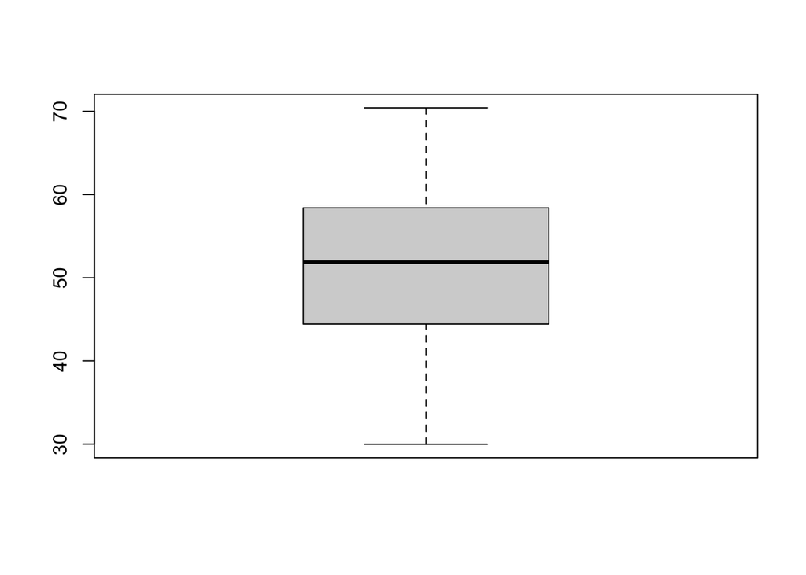

```r
boxplot(SLSII$age)
```

## Hist creates a histogram for the variable “age” in SLSII

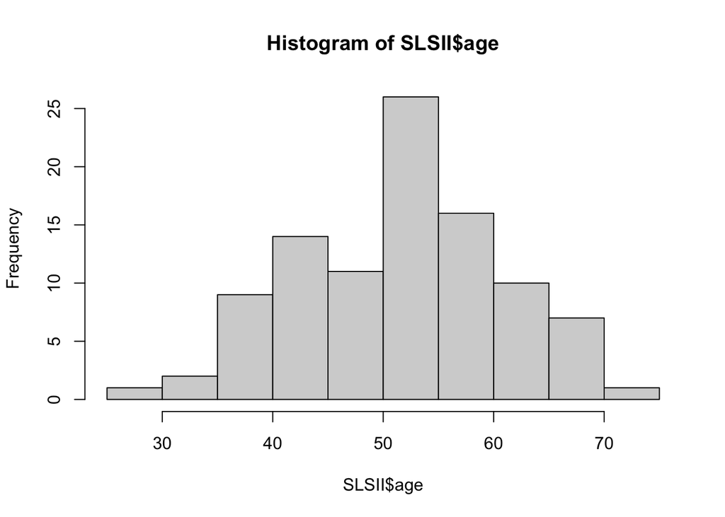

```r
hist(SLSII$age)
```

## Table creates a frequency table where 0 represents females and 1 represents males

```r
table(SLSII$Male)
```

```
##
##  0  1
## 72 25
```

## A table is created where the rows represent gender/sex and columns represent treatment type

```r
table(SLSII$Male, SLSII$Treatment)
```

```
##
##     CYC MMF
##   0  39  33
##   1   8  17
```

## The frequency values in the previous statement are now converted into proportions for the values which sum up to 1.00 horizontally. Also known as row-wise proportions

```r
prop.table(table(SLSII$Male, SLSII$Treatment), 1)
```

```
##
##           CYC       MMF
##   0 0.5416667 0.4583333
##   1 0.3200000 0.6800000
```

## Creates proportions going downward. Also known as column-wise proportions

```r
prop.table(table(SLSII$Male, SLSII$Treatment), 2)
```

```
##
##           CYC       MMF
##   0 0.8297872 0.6600000
##   1 0.1702128 0.3400000
```

## Creates porportions across all four boxes, or a grand total throughout the table

```r
prop.table(table(SLSII$Male, SLSII$Treatment))
```

```
##
##            CYC        MMF
##   0 0.40206186 0.34020619
##   1 0.08247423 0.17525773
```